# Notebook

### Web Information Retrieval and Data Mining - Assignment 3

```
Student: HOFFMAN, WOUTER (0899958)
```

#### Answer 1.1, Baseline (4p)

- Dense network, at least 3 layers, shaped like a pyramid
  - Last layer: 10 nodes, sigmoid.
  - Loss: categorical cross-entropy. Metric: accuracy
- No preprocessing, regularization. Get at least 70% accuracy.
- Explain design decisions. Discuss performance.
  - Does it overfit (large/growing gap between loss and val_loss)?

[output not shown]

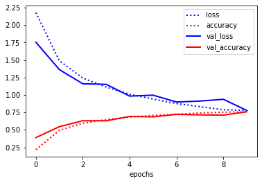

```
Model: "sequential_2"
_________________________________________________________________
Layer (type)                 Output Shape              Param #
=================================================================
reshape_2 (Reshape)          (None, 3072)              0
_________________________________________________________________
dense_4 (Dense)              (None, 512)               1573376
_________________________________________________________________
dense_5 (Dense)              (None, 256)               131328
_________________________________________________________________
dense_6 (Dense)              (None, 128)               32896
_________________________________________________________________
dense_7 (Dense)              (None, 64)                8256
_________________________________________________________________
dense_8 (Dense)              (None, 10)                650
=================================================================
Total params: 1,746,506
Trainable params: 1,746,506
Non-trainable params: 0
_________________________________________________________________
None
def build_model_1_1():

    # Initialize a sequential model
    model = models.Sequential()
    # input layer
    model.add(layers.Reshape((3072,), input_shape=(32,32,3)))
    # Hidden layers
    model.add(layers.Dense(512, activation='relu'))
    model.add(layers.Dense(256, activation='relu'))
    model.add(layers.Dense(128, activation='relu'))
    model.add(layers.Dense(64, activation='relu'))
    # Output layer
    model.add(layers.Dense(10, activation='softmax'))
    # Compile model
    model.compile(optimizer='adam', loss='categorical_crossentropy', metrics=['accuracy'])


    return model

    pass
```

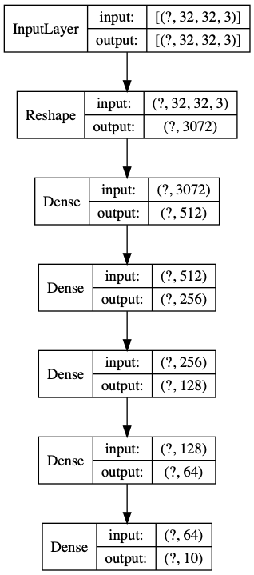

#### Answer 1.2, Preprocess (2p)

- Convert images to greyscale, other preprocessing optional.
  - Input shape should be (32,32,1)
- Explain design decisions. Is it better? Why (not)?
  - Color information is likely not so useful for classification. Greyscale makes the network smaller, less parameters to learn, less likely to overfit.

[output not shown]

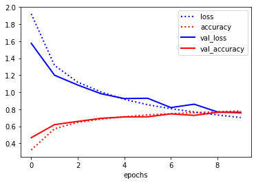

```
Model: "sequential_3"
_________________________________________________________________
Layer (type)                 Output Shape              Param #
=================================================================
reshape_3 (Reshape)          (None, 1024)              0
_________________________________________________________________
dense_9 (Dense)              (None, 512)               524800
_________________________________________________________________
dense_10 (Dense)             (None, 256)               131328
_________________________________________________________________
dense_11 (Dense)             (None, 128)               32896
_________________________________________________________________
dense_12 (Dense)             (None, 64)                8256
_________________________________________________________________
dense_13 (Dense)             (None, 10)                650
=================================================================
Total params: 697,930
Trainable params: 697,930
Non-trainable params: 0
_________________________________________________________________
None
def build_model_1_2():

    # Initialize a sequential model
    model = models.Sequential()
    # input layer
    model.add(layers.Reshape((1024,), input_shape=(32,32,1)))
    # Hidden layers
    model.add(layers.Dense(512, activation='relu'))
    model.add(layers.Dense(256, activation='relu'))
    model.add(layers.Dense(128, activation='relu'))
    model.add(layers.Dense(64, activation='relu'))
    # Output layer
    model.add(layers.Dense(10, activation='softmax'))
    # Compile model
    model.compile(optimizer='adam', loss='categorical_crossentropy', metrics=['accuracy'])


    return model

    pass
```

#### Answer 1.3, Tune (4p)

- Regularize the model. What works best?
  - Should consider batch normalization, dropout, l1/l2 regularization (or Nesterov)
- Tune other hyperparameters (e.g. learning rate, batch size,...) as you see fit.
  - At least consider tuning learning rate, ideally also momentum, decay, other optimizers
- Explain your findings and final design decisions. Discuss the results.
  - Should be better, at least it shouldn't overfit

```
 (length: 1)

Max val score: 81.11%
```

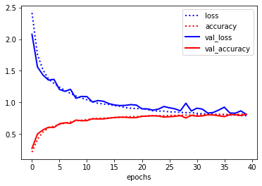

```
def build_model_1_3():

    # Initialize a sequential model
    model = models.Sequential()
    # input layer
    model.add(layers.Reshape((1024,), input_shape=(32,32,1)))
    # Hidden layers
    model.add(layers.Dense(512, activation='relu', kernel_regularizer=regularizers.l2(0.001)))
    model.add(layers.Dense(256, activation='relu', kernel_regularizer=regularizers.l2(0.001)))
    model.add(layers.Dense(128, activation='relu', kernel_regularizer=regularizers.l2(0.001)))
    model.add(layers.Dense(64, activation='relu', kernel_regularizer=regularizers.l2(0.001)))

    # Output layer
    model.add(layers.Dense(10, activation='softmax'))
    # Compile model
    model.compile(optimizer='adam', loss='categorical_crossentropy', metrics=['accuracy'])

    return model

    pass
```

#### Answer 2.1, ConvNet (7p)

- Build a sequential ConvNet, get at least 90% accuracy.
  - Conv2D layers, input shape (32,32,1)
  - Consider using blocks of Conv2D layers with maxpooling in between
  - Use zero-padding in Conv2D layers because the images are small
  - At least one dense hidden layer and dense output layer (sigmoid)
  - Consider adding batch normalization, dropout
  - Consider small dropout rates in beginning, larger dropout rates later in network
  - Consider other optimizers and tuning learning rate, momentum,...
- Explain what you did and why (800 chars). Is it working well?
  - Should be quite elaborate and sensible

```
(length: 0)

Max val score: 94.54%
```

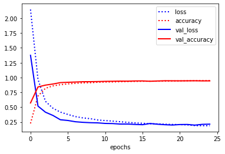

```
Model: "sequential_5"
_________________________________________________________________
Layer (type)                 Output Shape              Param #
=================================================================
conv2d (Conv2D)              (None, 32, 32, 32)        320
_________________________________________________________________
conv2d_1 (Conv2D)            (None, 32, 32, 32)        9248
_________________________________________________________________
max_pooling2d (MaxPooling2D) (None, 16, 16, 32)        0
_________________________________________________________________
dropout (Dropout)            (None, 16, 16, 32)        0
_________________________________________________________________
conv2d_2 (Conv2D)            (None, 16, 16, 64)        18496
_________________________________________________________________
conv2d_3 (Conv2D)            (None, 16, 16, 64)        36928
_________________________________________________________________
max_pooling2d_1 (MaxPooling2 (None, 8, 8, 64)          0
_________________________________________________________________
dropout_1 (Dropout)          (None, 8, 8, 64)          0
_________________________________________________________________
conv2d_4 (Conv2D)            (None, 8, 8, 64)          36928
_________________________________________________________________
conv2d_5 (Conv2D)            (None, 8, 8, 64)          36928
_________________________________________________________________
max_pooling2d_2 (MaxPooling2 (None, 4, 4, 64)          0
_________________________________________________________________
dropout_2 (Dropout)          (None, 4, 4, 64)          0
_________________________________________________________________
flatten (Flatten)            (None, 1024)              0
_________________________________________________________________
dense_19 (Dense)             (None, 64)                65600
_________________________________________________________________
dropout_3 (Dropout)          (None, 64)                0
_________________________________________________________________
dense_20 (Dense)             (None, 10)                650
=================================================================
Total params: 205,098
Trainable params: 205,098
Non-trainable params: 0
_________________________________________________________________
```

[output cut: 19 more lines]

```
    # Flatten convolution part of model
    model.add(layers.Flatten())
    # Add one last non-convolutional hidden layer to interpret the convolutional base of the model and continue with dropouts
    model.add(layers.Dense(64, activation='relu'))
    model.add(layers.Dropout(0.4))
    # Add the output layer
    model.add(layers.Dense(10, activation='softmax'))
    # Compile the model
    model.compile(optimizer='adam',
              loss='categorical_crossentropy',
              metrics=['accuracy'])

    return model

    pass
```

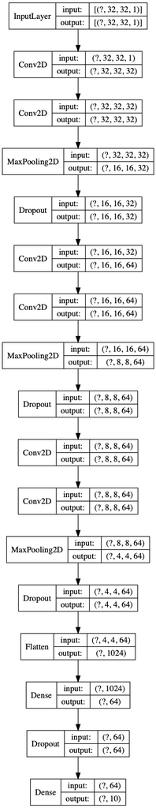

#### Answer 2.2, Data Augmentation (3p)

- Augment the preprocessed training data.
  - Use small variations (small shifts up-down, left-right) of flips becasue the images are small
  - Large shifts and rotations distort the image too much
- Explain what you did and why. Discuss the performance of the model.

[output not shown]

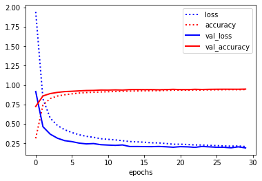

[output not shown]

#### Answer 3.1, Misclassifications (2p)

```
(length: 0)

Test score: 0.95%
```

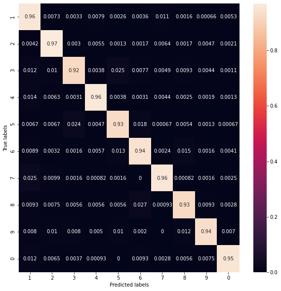

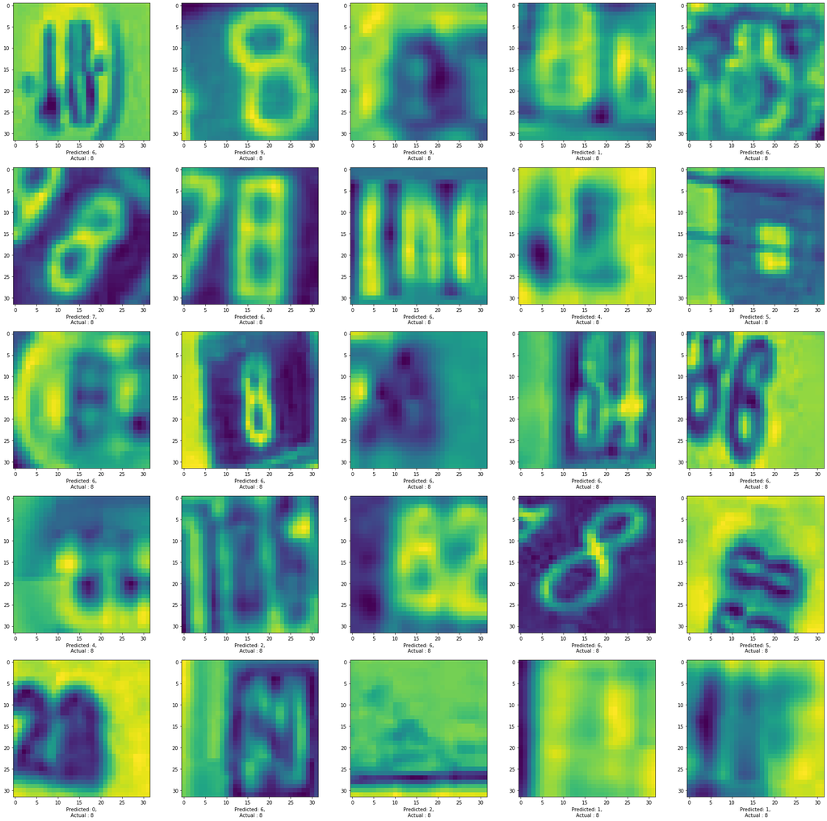

#### Answer 3.2, Activations (4p)

- Retrieve and visualize the activations for one example
- For every filter for different convolutional layers (at different depths in the network).
- Give an explanation. Is your model indeed learning something useful?
  - Should detect edges etc in first layers, higher-order object (e.g. interesting regions) in deeper layers.

```
(length: 0)
```

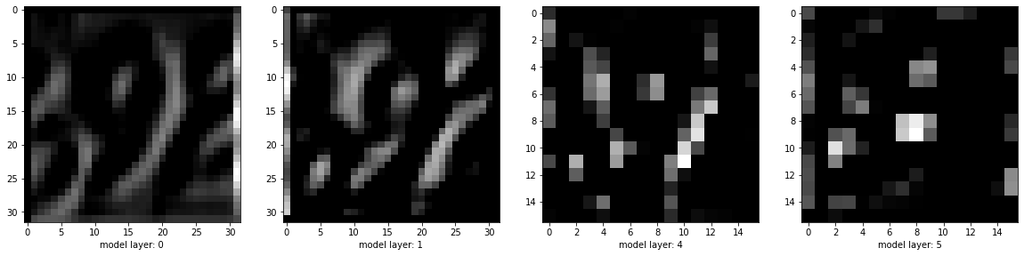

#### Answer 3.3, Class activation map (4p)

- Show a class activation map for your last convolutional layer
- Superimpose the activation map over the image, or plot side by side
  - Should make sense, detect interesting regions to classify the number

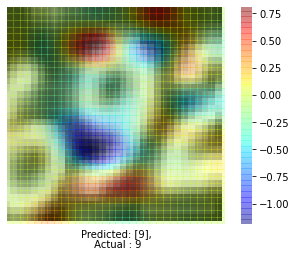

```
def plot_3_3():

    # LOAD MODEL AND IMAGE SAMPLE
    # Load the model
    model = load_model_from_file(base_dir, 'model_2_2', extension='.h5')
    # Select first image of test set as sample
    img = augmented_split[1][0]
    img = np.expand_dims(img, axis=0)

    # STORE PREDICTED AND TRUE LABELS
    # Get the models class prediction for the sample, and the corresponding actual number
    pred = model.predict_classes(img)
    pred_original = to_original_label(pred)
    # Get the actual label and number
    actual = np.argmax(augmented_split[3][0])
    actual_original = to_original_label(actual)

    # CALCULATE ACTIVATION MAP
    # Get the weights of the last layer
    weights = model.layers[-1].get_weights()[0]
    # Create a new model based that accepts the same input, and has the last convolutional layer as output layer, so it returns the activations in the final layer to us
    activation_model = Model(inputs=model.inputs, outputs=model.layers[9].output)
    activations = activation_model.predict(img)
    # Get weights of last layer for the predicted label
    activation_weights = weights[:,pred]
    # Calculate the dot product between the activations from the activation_model's prediction and the weights belonging to the predicted class
    activation_map = np.dot(activations, activation_weights)

    # PREPARE IMAGES FOR PLOTTING
    # Reduce map to 2 dimensions so it is suitable for plotting
    activation_map = np.squeeze(activation_map, axis = 3)
    activation_map = np.squeeze(activation_map, axis = 0)
    # Resize activation map to 32x32
    activation_map = cv2.resize(activation_map, dsize=(32, 32), interpolation=cv2.INTER_CUBIC)

    # Prepare sample image for plotting
    img = np.squeeze(img, axis=3)
    img = np.squeeze(img, axis=0)


    # PLOT
    # Superimpose images
    plt.imshow(img, cmap= 'gray')
    heatmap = sn.heatmap(activation_map, annot=False, alpha = 0.28, cmap='jet')
    heatmap.set_xticks(())
    heatmap.set_yticks(())

    plt.xlabel("Predicted: %s,\n Actual : %s" % (pred_original, actual_original))
    # show plot
    plt.show()

    pass
```

#### Answer 4.1, Fast feature extraction (5p)

- Import the VGG16 model, pretrained on ImageNet
- Freeze convolutional base, adds a dense layer
- Consider unfreezing the last few convolutional layers and evaluate whether that works better
  - Check if they do. It is very likely to help.
- Discuss the observed performance
  - Should get around 80% accuracy

```
(length: 0)

Max val score: 79.76%
```

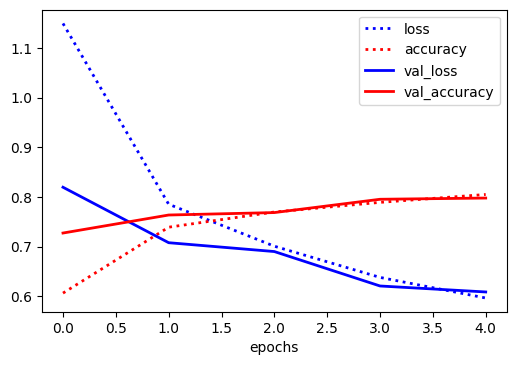

```
Model: "sequential_14"
_________________________________________________________________
Layer (type)                 Output Shape              Param #
=================================================================
vgg16 (Model)                (None, 1, 1, 512)         14714688
_________________________________________________________________
dropout_18 (Dropout)         (None, 1, 1, 512)         0
_________________________________________________________________
flatten_9 (Flatten)          (None, 512)               0
_________________________________________________________________
dense_37 (Dense)             (None, 128)               65664
_________________________________________________________________
dropout_19 (Dropout)         (None, 128)               0
_________________________________________________________________
dense_38 (Dense)             (None, 10)                1290
=================================================================
Total params: 14,781,642
Trainable params: 2,426,762
Non-trainable params: 12,354,880
_________________________________________________________________
None
def build_model_4_1():

    model = models.Sequential()
    # Load the VGG convolutional models
    conv_base = VGG16(weights='imagenet', include_top=False, input_shape = (32, 32, 3))

    # unfreeze the last layer
    set_trainable = False
    for layer in conv_base.layers:
        if layer.name == 'block5_conv1':
            set_trainable = True
        else:
            layer.trainable = False

    # Build the model
    model.add(conv_base)
    model.add(layers.Dropout(0.3))
    model.add(layers.Flatten())
    model.add(layers.Dense(128, activation='relu'))
    model.add(layers.Dropout(0.3))
    model.add(layers.Dense(10, activation='softmax'))
    # Compile model
    model.compile(optimizer='adam',
              loss='categorical_crossentropy',
              metrics=['accuracy'])

    return model
    pass
```

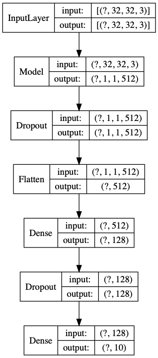

#### Answer 4.2, Embeddings (5p)

- Generate embeddings with the trained convolutional part of model_4_1 (without the dense layer)
- Embed the training and test data and store them to disk
- Build and evaluate a pipeline on the embedded data
  - Check if pipeline makes sense (e.g. use models that can handle many dimensions)
- Describe what you did and what you observed (max 800 chars).
  - Consider different models, preprocessing, tuning, etc.
  - Check performance (see original Submission.html) when in doubt. We did not run all the evaluations because it takes too long, and the output is ill-defined.

```
(length: 0)

Pipeline(steps=[('standardscaler', StandardScaler()), ('svc', SVC())])
def store_embeddings():
    """ Stores all necessary embeddings to file
    """
    # load model_4_1
    model_4_1 = load_model_from_file(base_dir, 'model_4_1', extension='.h5')
    # Initialize a new model
    model = models.Sequential()
    # Add the convolutional part of model_4_1 to our model
    for layer in model_4_1.layers[:3]:
            model.add(layer)

    # Perform predictions with model
    embedded_train = model.predict(evaluation_split[0])
    embedded_test = model.predict(evaluation_split[1])
    # Store the embedded datasets
    store_embedding(embedded_train, 'train')
    store_embedding(embedded_test, 'test')

    pass

def evaluation_4_2(X_train, y_train, X_test, y_test):
    """ Runs 'evaluate_pipeline' with embedded versions of the input data
    and returns the accuracy.
    """
    # Generate pipeline
    pipe = generate_pipeline()
    # Evaluate pipeline on embedded data
    evaluate_pipeline(pipe, X_train_embed, y_train ,X_test_embed, y_test)

    pass
```

```
Running time: 13.58 seconds
Last modified: May 26, 2020
scikit-learn version: 0.23.1
```